# Principal Components Analysis

David Gerard

1/7/2020

## Fitting PCA

We’ll load the data from the magnetic force example into R:

```r
library(Sleuth3)
data("case1701")
magnet <- case1701[, paste0("L", 1:11)]
head(magnet)
```

```
##    L1  L2  L3  L4  L5  L6  L7  L8   L9  L10  L11
## 1 136 142 139 131 122 118 134 138  148  149  171
## 2 639 723 782 756 804 804 909 962 1042 1058 1022
## 3 673 709 709 719 682 681 759 912 1122 1121  900
## 4 471 501 521 519 528 521 540 523  548  525  513
## 5 578 617 650 625 632 634 677 695  733  735  747
## 6 120 124 110 110 101 104 126 140  158  164  182
```

You can use `prcomp()` to find the principle components in R:

```r
prout <- prcomp(x = magnet)
prout
```

```
## Standard deviations (1, .., p=11):
##  [1] 804.331021 131.327404  68.439470  30.124733  21.210565  15.555443
##  [7]   9.646885   7.888545   5.206570   3.942521   3.486787
##
## Rotation (n x k) = (11 x 11):
##           PC1         PC2           PC3          PC4         PC5
## L1  0.2227509 -0.30399160  0.2588810743 -0.092357875  0.72749952
## L2  0.2326776 -0.26519901  0.2699820740 -0.050181695  0.20334212
## L3  0.2389504 -0.25952546  0.2910850089 -0.008376658 -0.33349245
## L4  0.2485963 -0.26379634  0.2927069729  0.021468932 -0.14454117
## L5  0.2626644 -0.30677089  0.0671552041  0.127594004 -0.36697246
## L6  0.2900818 -0.38766455 -0.7910774319 -0.209102118  0.10290952
## L7  0.3094757 -0.08321678 -0.2007339621  0.259607531 -0.22212511
## L8  0.3360308  0.17851807  0.0781530595  0.089106944 -0.13468403
## L9  0.3769142  0.36968982  0.0547882501 -0.430716689 -0.07530357
## L10 0.3791905  0.40445558  0.0004963571 -0.394391020  0.03972393
## L11 0.3600888  0.34187106 -0.0998251822  0.715555414  0.27802868
##             PC6           PC7         PC8         PC9        PC10
## L1  -0.29490482 -0.2208972953  0.16231172 -0.27562637  0.11600420
## L2   0.32537791  0.4261974303  0.05937071  0.62334047  0.07197327
## L3   0.41455666  0.2701563674  0.16945333 -0.61970037  0.13094406
## L4  -0.07929748 -0.1025154901 -0.43189742  0.16068495 -0.49543590
## L5  -0.07267840 -0.6011400613 -0.15205054  0.10092544  0.23369420
## L6   0.09296544  0.1346933454 -0.19046927 -0.10597245 -0.10055251
## L7  -0.25529106 -0.0002622996  0.63853587  0.26185595  0.17133804
## L8  -0.56747202  0.4050127099  0.01296568 -0.16005876 -0.35688302
## L9  -0.16342611  0.1087179292 -0.34178201  0.05107487  0.57089091
## L10  0.34468768 -0.3603319671  0.33391646  0.02982406 -0.40870431
## L11  0.28700980 -0.0293342398 -0.24345632 -0.08078979  0.06601630
##            PC11
## L1  -0.04037035
## L2   0.27203061
## L3  -0.06928476
## L4  -0.53569733
## L5   0.47630910
## L6   0.03235459
## L7  -0.41163462
## L8   0.42873611
## L9  -0.20786568
## L10  0.08619797
## L11 -0.02800802
```

The element `rotation` contains the a matrix where the columns index the principal components. The rows index the variables (the 11 measurements) and the columns index the principal compoenents. These are the coefficients that apply a weight to each of the observed variables (the C’s).

```r
prout$rotation
```

```
##           PC1         PC2           PC3          PC4         PC5
## L1  0.2227509 -0.30399160  0.2588810743 -0.092357875  0.72749952
## L2  0.2326776 -0.26519901  0.2699820740 -0.050181695  0.20334212
## L3  0.2389504 -0.25952546  0.2910850089 -0.008376658 -0.33349245
## L4  0.2485963 -0.26379634  0.2927069729  0.021468932 -0.14454117
## L5  0.2626644 -0.30677089  0.0671552041  0.127594004 -0.36697246
## L6  0.2900818 -0.38766455 -0.7910774319 -0.209102118  0.10290952
## L7  0.3094757 -0.08321678 -0.2007339621  0.259607531 -0.22212511
## L8  0.3360308  0.17851807  0.0781530595  0.089106944 -0.13468403
## L9  0.3769142  0.36968982  0.0547882501 -0.430716689 -0.07530357
## L10 0.3791905  0.40445558  0.0004963571 -0.394391020  0.03972393
## L11 0.3600888  0.34187106 -0.0998251822  0.715555414  0.27802868
##             PC6           PC7         PC8         PC9        PC10
## L1  -0.29490482 -0.2208972953  0.16231172 -0.27562637  0.11600420
## L2   0.32537791  0.4261974303  0.05937071  0.62334047  0.07197327
## L3   0.41455666  0.2701563674  0.16945333 -0.61970037  0.13094406
## L4  -0.07929748 -0.1025154901 -0.43189742  0.16068495 -0.49543590
## L5  -0.07267840 -0.6011400613 -0.15205054  0.10092544  0.23369420
## L6   0.09296544  0.1346933454 -0.19046927 -0.10597245 -0.10055251
## L7  -0.25529106 -0.0002622996  0.63853587  0.26185595  0.17133804
## L8  -0.56747202  0.4050127099  0.01296568 -0.16005876 -0.35688302
## L9  -0.16342611  0.1087179292 -0.34178201  0.05107487  0.57089091
## L10  0.34468768 -0.3603319671  0.33391646  0.02982406 -0.40870431
## L11  0.28700980 -0.0293342398 -0.24345632 -0.08078979  0.06601630
##            PC11
## L1  -0.04037035
## L2   0.27203061
## L3  -0.06928476
## L4  -0.53569733
## L5   0.47630910
## L6   0.03235459
## L7  -0.41163462
## L8   0.42873611
## L9  -0.20786568
## L10  0.08619797
## L11 -0.02800802
```

The element `x` contains the matrix of linear combinations (the new variables). The rows index the observational/experimental units (44 conditions here) and the columns index the corresponding principle components.

```r
prout$x
```

```
##              PC1         PC2          PC3           PC4         PC5
##  [1,] -1427.9775   65.235770  -20.0984711    2.32237936   0.8573597
##  [2,]  1011.2171   23.035146   13.5184985   18.31321187 -77.2583125
##  [3,]   868.0550  147.131059  118.3663757 -164.15238144   9.0474131
##  [4,]  -187.0348 -162.262784   33.3284974  -10.11857913 -35.5604226
##  [5,]   314.8777 -110.073906   51.3387316   20.84229811 -13.1357567
##  [6,] -1445.8427  114.355756  -32.8043038    0.49283795   8.9383147
##  [7,]   251.7147  -42.628899   18.1297770   23.23230956  -0.4366607
##  [8,]   702.1596  118.733258   -1.2515198   11.94726532  -1.0756858
##  [9,]   722.3731  125.895164   -0.3657511   16.78695949  18.2080109
## [10,]  -298.7854 -171.344733   47.1699063  -17.65617781   6.1490412
## [11,] -1439.2045  103.368855  -31.8258918   -6.69222042  -7.5033022
## [12,]   709.2034  227.275848  -44.6555908   -7.58328632  -8.0758661
## [13,]  -370.5503 -140.031274   26.8146374  -13.27566361 -15.3762729
## [14,]   218.5087   24.251616  -16.3236050   11.23413407 -32.4622831
```

[output cut: 120 more lines]

Properties:

1. The principal components are ordered from those that explain the most vaiability in the data to those that explain the least.
2. The principal components are uncorrelated.

## Interpreting Coefficients

After you have the principal components, a key step is trying to interpret the components. You do this by looking at the coefficients and seeing what variables are heavily loaded onto each components

```r
prout$rotation[, 1, drop = FALSE]
```

```
##           PC1
## L1  0.2227509
## L2  0.2326776
## L3  0.2389504
## L4  0.2485963
## L5  0.2626644
## L6  0.2900818
## L7  0.3094757
## L8  0.3360308
## L9  0.3769142
## L10 0.3791905
## L11 0.3600888
```

First component nearly equally weights all variables. This indicates that is represents some total signal. E.g. rods that have a total magnetic force above average tend to have a larger PC1, rods that have a total magnetic force below average tend to have a smaller PC1.

The first principal component explains 96% of the variability (most of the variability is because magnets)

```r
prout$sdev[[1]]^2 / sum(prout$sdev^2)
```

```
## [1] 0.9646031
```

The second principal component contrasts two ends of the rod

```r
prout$rotation[, 2, drop = FALSE]
```

```
##             PC2
## L1  -0.30399160
## L2  -0.26519901
## L3  -0.25952546
## L4  -0.26379634
## L5  -0.30677089
## L6  -0.38766455
## L7  -0.08321678
## L8   0.17851807
## L9   0.36968982
## L10  0.40445558
## L11  0.34187106
```

Rods with higher PC2 tend to have higher force in positions 8-11 than in positions 1-6. Rods with lower PC2 tend ot have higher force in positions 1-6 than in 8-11.

The third principal component captures a peak at position 6

```r
prout$rotation[, 3, drop = FALSE]
```

```
##               PC3
## L1   0.2588810743
## L2   0.2699820740
## L3   0.2910850089
## L4   0.2927069729
## L5   0.0671552041
## L6  -0.7910774319
## L7  -0.2007339621
## L8   0.0781530595
## L9   0.0547882501
## L10  0.0004963571
## L11 -0.0998251822
```

# Plotting PC’s

It is common to plot the PC’s and look for clusters.

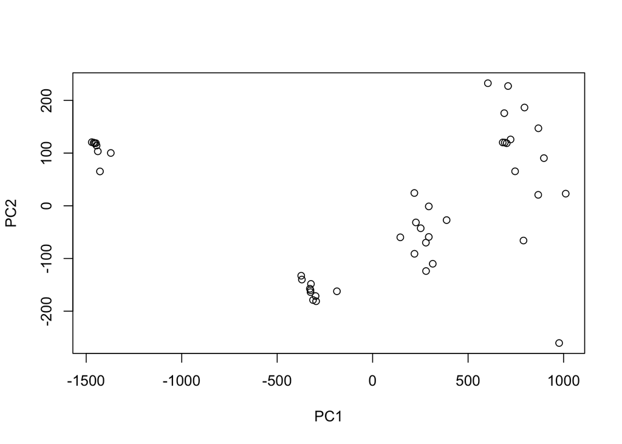

```r
plot(prout$x[, 1:2])
```

There are 4 clusters. We usually interpret this as meaning that there is a latent variable being picked up by the PC’s. In some settings, this might indicate quality control issues.

The below plot indicates that variation in PC3 is primarily due to one point:

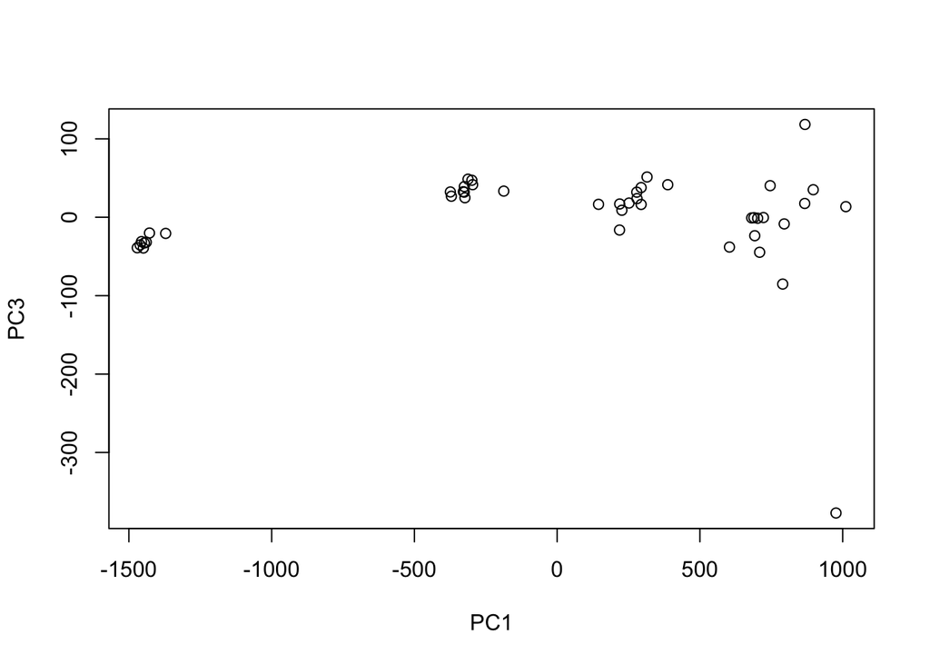

```r
plot(prout$x[, c(1, 3)])
```

You would want to explore that point.

## Considerations for PCA

PCA is scale sensitive. If you multiply a varible by 10 to get 10Y, then this variable has 100 times the variance of Y. If other variables remain unchanged, then PCA will put more attention on 10Y. You should normalize variables if they aren’t on the same scale already.

I don’t usually like using PCA on explanatory variables prior to regression. E.g., suppose a variable is highly correlated to the response, but does not contribute a lot of variability to the explanatory variables. If you use PCA first, you will destroy that variable.